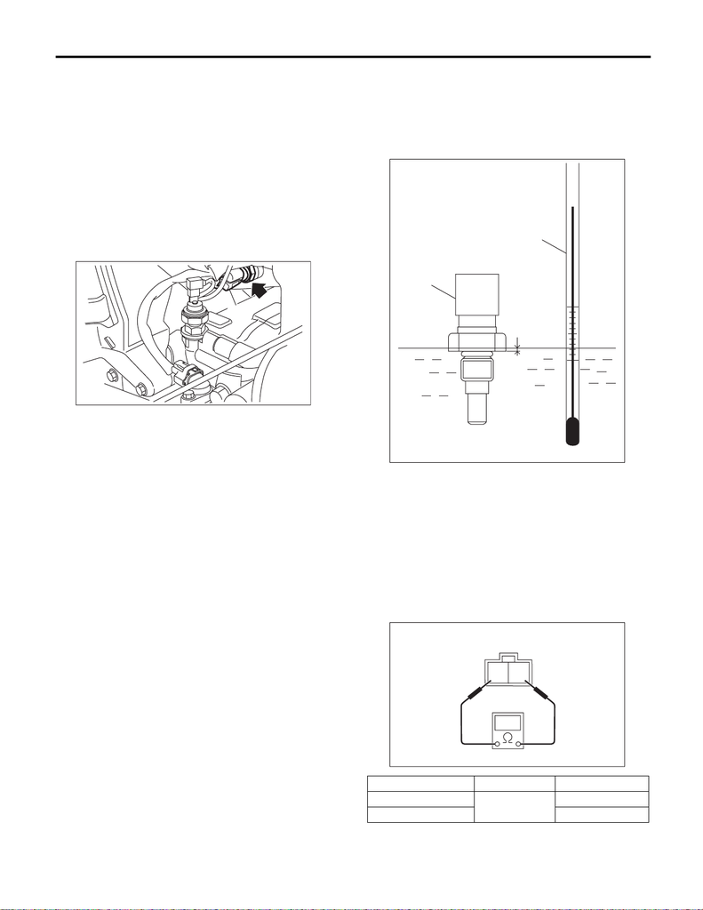

FU(STI)-33

Engine Coolant Temperature Sensor

FUEL INJECTION (FUEL SYSTEMS)

4. Engine Coolant Temperature

Sensor

A: REMOVAL

1) Disconnect the ground cable from battery.

2) Remove the generator. <Ref. to SC(STI)-15,

REMOVAL, Generator.>

3) Drain engine coolant. <Ref. to CO(STI)-13,

DRAINING OF ENGINE COOLANT, REPLACE-

MENT, Engine Coolant.>

4) Disconnect the connector (A) from the engine

coolant temperature sensor, and remove the en-

gine coolant temperature sensor.

B: INSTALLATION

Install in the reverse order of removal.

NOTE:

Use a new gasket.

Tightening torque:

18 N·m (1.8 kgf-m, 13.3 ft-lb)

C: INSPECTION

1) Check that the engine coolant temperature sen-

sor has no deformation, cracks or other damages.

2) Immerse the engine coolant temperature sensor

and a thermometer in water.

CAUTION:

Take care not to allow water to get into the en-

gine coolant temperature sensor connector.

Completely remove any water inside.

3) Raise water temperature gradually, measure the

resistance between the engine coolant tempera-

ture sensor terminals when the temperature is

20°C (68°F) and 80°C (176°F).

NOTE:

Agitate the water for even temperature distribution.

(A)

FU-05796

(A) Thermometer

(B) Engine coolant temperature sensor

Water temperature Terminal No. Standard

20°C (68°F)

1 and 2

2.45±0.2 kΩ

80°C (176°F) 0.318±0.013 kΩ

FU-04053

(A)

(B)

(C)

2

1

EC-02428